# Relatório HATCO

## Guilherme Trindade, Henrique de Brito e Lucas Souza

### 05/10/2017

## Perfil do consumidor

O público consumidor da empresa é definido pelas faixas etárias: jovens e adultos, distribuídas pela área de abrangência composta por: capital, região metropolitana e interior.

Percebe-se pelos dados fornecidos e expostos nos gráficos abaixo que a maior mediana do nível de uso (compras) ocorreu na região do interior com a avaliação aproximada do nível 55 - região composta por mais de 90% pela faixa etária jovem, que estão mais acostumados com o uso da Internet - e a menor mediana do nível de uso (compras) ocorreu na capital e foi avaliada com, aproximadamente, o nível 38, sendo essa região composta, em média, por 80% de adultos - que fazem uso eventual da Internet.

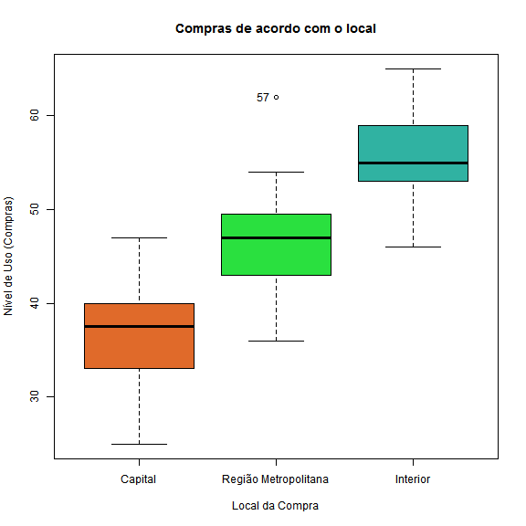

```
[1] "57"
```

```r
> Boxplot(Nível.de.Uso~Local.da.Compra, data=empresa, id.method="y", xlab="Local da Compra",
+   ylab="Nível de Uso (Compras)", col=c("#e06a2a","#2ae03f","#30b2a2"), main="Compras de acordo com o local")
```

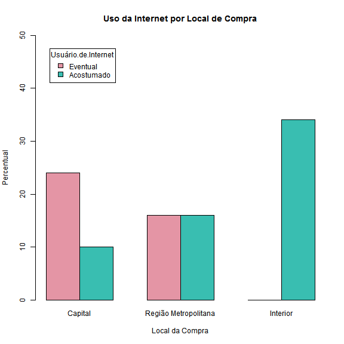

```r
> with(empresa, Barplot(Local.da.Compra, by=Usuário.de.Internet, style="parallel", legend.pos="topleft",
+   xlab="Local da Compra", ylab="Percentual", main="Uso da Internet por Local de Compra", ylim=c(0,50)))
```

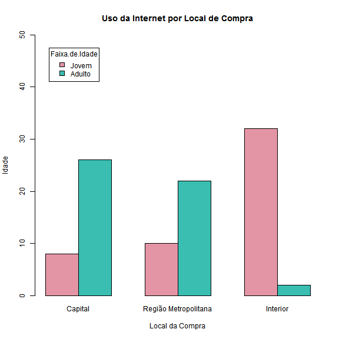

```r
> with(empresa, Barplot(Local.da.Compra, by=Faixa.de.Idade, style="parallel", legend.pos="topleft",
+   xlab="Local da Compra", ylab="Idade", main="Uso da Internet por Local de Compra", ylim=c(0,50)))
```

## Mix de Marketing

### • Produtos

Procurou-se avaliar a relevância de algumas variáveis na definição da popularidade do produto - todos de acordo com a faixa etária. Tal análise foi divida em 3 partes, com 2 perspectivas cada:

#### 1 - Qualidade com Preço

Adulto - Percebe-se uma correlação ínfima entre estas variáveis. Não é perceptível a diferença de qualidade com o aumento do preço.

Jovem - Entende-se que o jovem não liga tanto para o aumento da qualidade com a diferença de preço porque ele opta por produtos mais baratos. No entanto, é levemente mais perceptível a eles a melhora na qualidade.

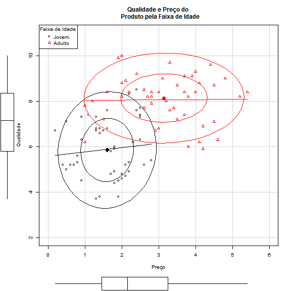

```r
> scatterplot(Qualidade.do.Produto~Preço.do.Produto | Faixa.de.Idade, reg.line=lm, smooth=FALSE, spread=FALSE,
+   boxplots='xy', span=0.5, ellipse=TRUE, levels=c(.5, .9), xlab="Preço", ylab="Qualidade", main="Qualidade e Preço do
+   Produto pela Faixa de Idade", by.groups=TRUE, legend.coords="topleft", data=empresa, xlim=c(0,6), ylim=c(2,11))
```

#### 2 - Qualidade com Satisfação

Adulto - Estranhamente, estes ficam menos satisfeitos com o aumento da qualidade. Talvez seja por terem pago mais caro e não perceberem uma diferença que valha a pena, como avaliado anteriormente.

Jovem - Mostra-se mais satisfeito com o aumento da qualidade, mesmo que o nível de qualidade seja menor comparado ao adulto. Isso talvez ocorra pelo menor poder de compra do jovem.

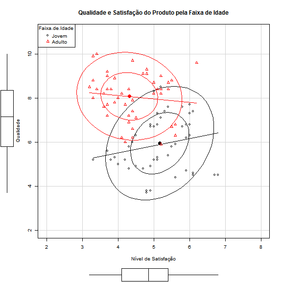

```r
> scatterplot(Qualidade.do.Produto~Nível.de.Satisfação | Faixa.de.Idade, reg.line=lm, smooth=FALSE, spread=FALSE,
+   boxplots='xy', span=0.5, ellipse=TRUE, levels=c(.5, .9), xlab="Nível de Satisfação", ylab="Qualidade",
+   main="Qualidade e Satisfação do Produto pela Faixa de Idade", by.groups=TRUE, legend.coords="topleft", data=empresa, xlim=c(2,8), ylim=c(2,11))
```

#### 3 - Preço com Satisfação

Adulto - Quanto maior o preço, maior a satisfação. Talvez seja um retrato da mentalidade adulta atual em busca de status - o que, para muitos, se obtém com produtos caros.

Jovem - O nível de satisfação de acordo com o preço para o jovem não é tão alto para que seja comparável, mas ainda sim obtém uma linha crescente. Pode ser que a mesma mentalidade dos adultos ainda está em processo de formação nesses jovens.

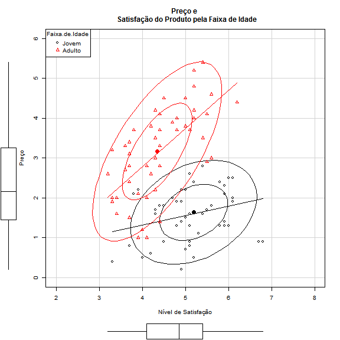

```r
> scatterplot(Preço.do.Produto~Nível.de.Satisfação | Faixa.de.Idade, reg.line=lm, smooth=FALSE, spread=FALSE,
+   boxplots='xy', span=0.5, ellipse=TRUE, levels=c(.5, .9), xlab="Nível de Satisfação", ylab="Preço", main="Preço e
+   Satisfação do Produto pela Faixa de Idade", by.groups=TRUE, legend.coords="topleft", data=empresa, xlim=c(2,8), ylim=c(0,6))
```

#### Em suma, ao correlacionar essas variáveis ao grupo de pessoas como um todo, infere-se correlações consideráveis entre Preço e Qualidade, nulas entre Satisfação e Preço e negativas entre Satisfação e Qualidade.

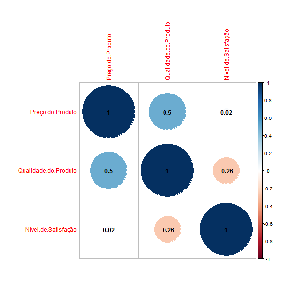

```r
> M<-cor(empresa[,c("Preço.do.Produto","Qualidade.do.Produto","Nível.de.Satisfação")], method="spearman", use="complete")
> require(corrplot)
> corrplot(M,addCoef.col=TRUE,number.cex=1.0)
```

### • Preço

O consumidor avaliou numa escala de entre: 1=barato e 6=caro, o valor mediano de aproximadamente 2, e sobre a flexibilidade do preço de acordo com a forma de pagamento atribuiu um valor de aproximadamente 8, numa escala de 1=menor flexibilidade a 10=maior flexibilidade. Portanto a precificação e formas de pagamento, não são um fator que atrapalhem por enquanto as vendas por tenderem a preços baratos e com maior flexibilidade segundo o consumidor.

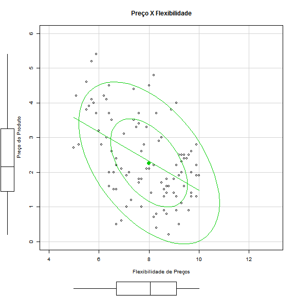

```r
> scatterplot(Preço.do.Produto~Flexibilidade.de.Preços, reg.line=lm, smooth=FALSE, spread=FALSE, boxplots='xy',
+   span=0.5, ellipse=TRUE, levels=c(.5, .9), xlab="Flexibilidade de Preços", ylab="Preço do Produto",
+   main="Preço X Flexibilidade", data=empresa, xlim=c(4,13), ylim=c(0,6))
```

### • Praça

Percebeu se que a velocidade de entrega tem bastante correlação com nível de uso (compras), se considerados os locais de compra.

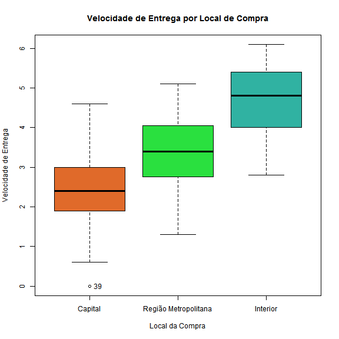

```
[1] "39"
```

```r
> Boxplot(Velocidade.de.Entrega~Local.da.Compra, data=empresa, id.method="y", xlab="Local da Compra",
+   ylab="Velocidade de Entrega", main="Velocidade de Entrega por Local de Compra", col=c("#e06a2a","#2ae03f","#30b2a2"))
```

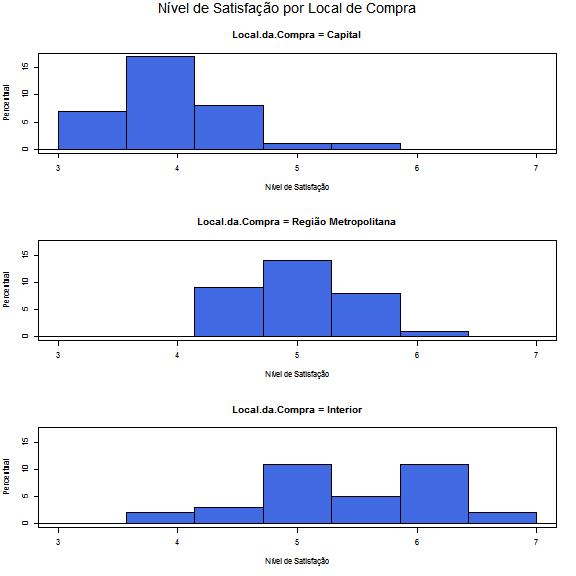

```r
> with(empresa, Hist(Nível.de.Satisfação, groups=Local.da.Compra, scale="frequency", breaks="Sturges", col="royalblue",
+   xlab="Nível de Satisfação", ylab="Percentual", main="Nível de Satisfação por Local de Compra"))
```

### • Promoção

Tendo em vista que a empresa realiza suas vendas pela internet, sendo essa sua única força de venda existente atualmente, o gráfico abaixo demonstra que a imagem dessa força foi avaliada por aproximadamente 60 % dos consumidores com o nível 2 a 3 de avaliação numa escala de 1 (péssima) a 5 (ótima). Tal avaliação aponta que a plataforma para as vendas via internet utilizada pode não ser tão aprazível para o consumidor, ainda mais se o consumidor for adulto e utilizar eventualmente a internet, é necessário, portanto alcançar esse público da capital com a melhora da atual força de venda, e se possível diversificar sua atuação.

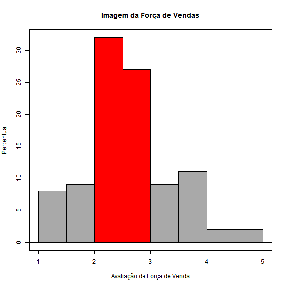

```r
> with(empresa, Hist(Imagem.da.Força.de.Vendas, scale="frequency", breaks="Sturges", col=c("darkgray", "darkgray", "red", "red", "darkgray", "darkgray"),
+   xlab="Avaliação de Força de Venda", ylab="Percentual", main="Imagem da Força de Vendas"))
```